# Basic Protocol 2: Differential Gene Expression Analysis with ideal

Annekathrin Ludt

Institute of Medical Biostatistics, Epidemiology and Informatics (IMBEI), Mainz  
anneludt@uni-mainz.de

Arsenij Ustjanzew

Institute of Medical Biostatistics, Epidemiology and Informatics (IMBEI), Mainz

Chung Shing Rex Ha

Institute of Medical Biostatistics, Epidemiology and Informatics (IMBEI), Mainz  
rexha@uni-mainz.de

Harald Binder

Institute of Medical Biometry and Statistics (IMBI), Faculty of Medicine and Medical Center, University of Freiburg  
binder@imbi.uni-freiburg.de

Konstantin Strauch

Institute of Medical Biostatistics, Epidemiology and Informatics (IMBEI), Mainz  
strauch@uni-mainz.de

Federico Marini

Institute of Medical Biostatistics, Epidemiology and Informatics (IMBEI), MainzCenter for Thrombosis and Hemostasis (CTH), Mainz;  
marinif@uni-mainz.de

30 September 2021

**Compiled date**: 2021-09-30

**Last edited**: 2021-09-30

# 1 Loading required packages

```r
library("DESeq2")
library("topGO")
library("org.Mm.eg.db")
library("pcaExplorer")
library("ideal")
library("GeneTonic")
```

# 2 Introductory Paragraph

ideal is a Bioconductor package (Marini, Linke, and Binder 2020) for the interactive analysis of RNA-seq data in the context of differential expression (DE) Love et al. (2015). ideal guides the user through different aspects of a DE analysis, starting from the data upload, through the DESeq2 workflow including normalization, filtering, exploration of differentially expressed genes, to functional analysis and gene signature exploration.

In this protocol we describe how to launch a Shiny application (Chang et al. 2021) of ideal with the data of the macrophage dataset (Alasoo et al. 2018) which is also distributed via Bioconductor Huber et al. (2015).

# 3 Necessary Resources

*Hardware*

a modern desktop computer or laptop with any up-to-date operating system

*Software*

*Files*

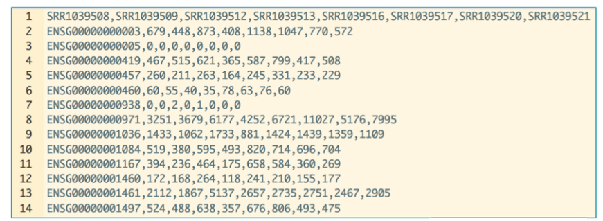

**Figure** Example of a count matrix - The figure shows the example of a count matrix, with the individual features (here genes) in the rows and the individual samples in the columns. The matrix represents how many times each feature was found in each sample. The shown count matrix is comma-separated, but also semicolon- and tab-separated inputs are accepted (see **Alternative protocol 1**)

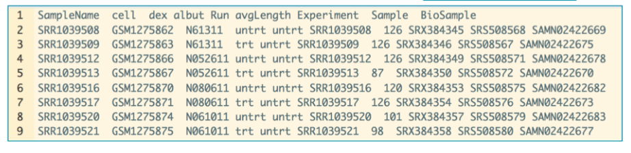

**Figure** Example of a Metadata file - The figure shows the example of a Metadata file. The rows of the file contain the individual samples while the columns represent relevant experimental variables. The variable can change depending on the data set and research question.

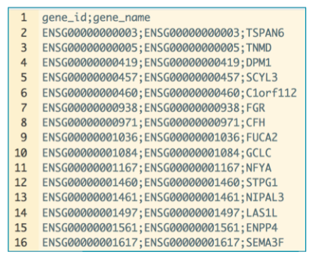

**Figure** Example of an annotation file - The annotation file contains a row for each of the features of the count matrix. Furthermore, the file contains at least one column called gene names which contains a more human readable for of the feature identifiers of the rows. In the shown example the feature ids are ENSEMBL ids while the column gene names contain HGNC gene names.

The last input of ideal is the Gene Matrix Transposed (GMT) format, which is commonly distributed e.g. by the widely used (MSigDB database)[http://software.broadinstitute.org/gsea/msigdb/index.jsp], or the (WikiPathways database)[http://data.wikipathways.org/]. The GMT file format is a tab delimited file format of gene sets, where each row represents a gene set. A gene set contains a gene set name in the first column, a description in the second column, and several genes in the remaining columns (one gene per column).

*Exploring the data with ideal*

Before we start with the exploration of the data, the necessary packages and dependencies need to be installed and loaded. **Support Protocol 1** describes how to install and load the packages.

1. Start application and provide the input data. The input data can be provided in different ways to the ideal application. The first option is to provide the data as R data.frames to the function `ideal()`, e.g. `ideal(countmatrix = countmatrix, expdesign = metadata, annotation_obj = annotation, gene_signatures = genesignatures)` where `countmatrix`, `metadata`, and `annotation` have to be data.frame objects, and `genesignatures` has to be a list object containing the previously described tables. The second option is to provide the data as a DESeqDataSet object or as a DESeqResult object, e.g. `ideal(dds) where`dds`is the DESeqDataSet object`. For inexperienced R users the third option is suitable, where the user interactively uploads the data as files in the ideal interface. For this option, launch the Shiny application with the R command `ideal()` without further arguments. All of these options should open a browser window with the ideal application.

When launching the application, the landing page of ideal is the “Welcome” panel providing the user information about the application and how to use it. A control sidebar is located on the left side of the user interface. It contains several input controls which affect different tab panels. By changing one or more of the input parameters, the user can get a fine control on what is computed and displayed. Moreover, the sidebar displays a list of the underlying objects with which basically all of the analysis can be performed. A green tick icon appears close to each when the respective component is either provided or calculated.

Navigate to the panel “Data setup.” Inspect or upload interactively the required count matrix, and the experimental design data in the red “Step 1” box. In the yellow “Step 2” box select the experiment design parameters. Select `line` and `condition` for the `macrophage` dataset and click on the green action button (“Generate the dds object”). This will enable you for example to estimate the effect size of the “condition” variable, while controlling for the “cell” line. After the DESeqDataSet object was generated, the ValueBox on top turns green, and also the sidebar field for it will get a green check mark. The two light blue boxes that have appeared provide the optional steps for adding the appropriate annotation and discarding unwanted samples. If you did not pass an annotation at application start, select `Human` as species for the macrophage dataset, `ENSEMBL` as the id type, and confirm the selection with the blue button “Retrieve the gene symbol annotation for the upload data.” Finally, run the main function of the DESeq2 framework in Step 3 (green box) by pushing the button “Run DESeq.” Once this is completed, you can inspect the mean-dispersion plot as a diagnostic check by expanding the collapsible element below.

2. Inspect and filter the count matrix. For this navigate to the panel “Counts Overview,” which provides an interactive table, which can display raw, normalized, and log-normalized values for all the genes and samples in the data. A summary for the expressed features is reported below. Set a threshold for either criterion to filter out the lowly expressed genes. This can also reduce the computation time without impacting the quality of the results. Filter the macrophage data with a threshold of zero on the row sums of the counts by pushing the “Filter the DDS object” button. Generate and inspect the sample-to-sample scatterplot matrix below which shows the similarity across all individual samples without losing the information on the single features - this can be quite useful for detecting unexpected patterns for subset of genes (Rutter et al. 2019).

6. Navigate to the panel “Gene Finder” and explore a subset of genes of interest. In this protocol we will define the genes CCL5, IFNGR1, and CXCL11 as genes of interest in the sidebar. The tab panel displays up to four gene expression boxplots for the selected genes, and also highlights the genes in the MA plot. Below the MA plot the user finds a downloadable and interactive table containing various relevant DE parameters to all differentially expressed genes. The user can search for features of interest or sort the table according to single columns. To avoid selecting many genes by hand (from the selectize widget in the sidebar), one can also upload a list as a plain text file containing one column of features with one feature per row. The genes from the uploaded file are highlighted in the MA plot below. Again, a downloadable, and interactive table visualizing the DE data of the uploaded genes appears below the last MA plot.

7. Navigate to the “Functional Analysis” tab to perform a gene set enrichment analysis on the differentially expressed genes and to gain insight on the affected biological pathways. Make sure, `GO Biological Proces` is set in the select widget called “Select the GO category(ies) of interest.” Here, the user can select from the three GO categories 1. `GO Biological Proces`, 2. `GO Molecular Function`, and 3. `GO Cellular Component`. The gene set enrichment analysis can be performed either only on upregulated (tab panel “UPregu”), on downregulated (tab panel “DOWNregu”), or on both up- and downregulated genes (tab panel “UPDOWN”). Additionally, up to two custom gene lists can be uploaded in the respective tab panels “List1” and “List2.” Navigate to the “UPDOWN” tab panel to perform the gene set enrichment analysis on the up- and downregulated features. Three methods of overrepresentation analysis (ORA) are available: 1. The standard ORA based on the limma package [PMC4402510], 2. the `goseq` ORA, which accounts for the specific length bias intrinsic in RNA-Seq assays (longer genes have higher chances of being called DE), and 3. the `topGO` ORA, which decorrelates the Gene Ontology graph structure and is particularly valuable for pruning terms which are topologically less meaningful than their specific nodes. Perform the analysis with `topGO` by clicking on the button called “Perform gene set enrichment analysis in the up- and downregulated genes - topGO.” An interactive, and downloadable table appears listing the relevant GO terms and further data, e.g. the list of differentially expressed genes respective to the GO term. Click on the blue button of the GO term `GO:0060333` to get further information from the [AmiGO](http://amigo.geneontology.org/amigo) database. As shown in the “Term” column of the interactive table, this GO term is associated with the interferon-gamma-mediated signaling pathway. Click on the row of the GO term `GO:0060333` to inspect the appearing heatmap. The heatmap displays all the all the differentially expressed genes annotated to the particular term colored by the normalized transformed values. This allows to compare the gene expression between the samples. Further down the page, explore the intersection between the uploaded gene lists and the regulated gene set. Tag the options `Use up regulated genes`, `Use down regulated genes`, and remove the checks from the remaining options to get a Venn diagramm of up- and downregulated features, as well as the appealing alternative from the `UpSetR` package [PMC5870712], where all combination of sets are explicitly shown.

8. Navigate to the “Signature Explorer” panel. Upload the `h.all.v7.0symbols.gmt` file retrieved from the [MSigDB](http://software.broadinstitute.org/gsea/downloads.jsp) (please refer to the **Alternative protocol 1** for further detail on downloading the file). The central green info box will report the number of signatures contained - in this case 50 signatures are present in the uploaded GMT file. Compute the variance stabilized transformated data by clicking of the equally named button. To match the identifier types of your data with the signatures, select `ENSEMBL` as the ID type in your dds data, `SYMBOL` as the ID type of your signatures, and `org.Hs.eg.db` as the organism package for matching. Click the button “Apply id conversion between data and signatures” to compute the matching. Further, select the gene signature of interest, e.g. `HALLMARK_INTERFERON_GAMMA_RESPONSE` and `condition` in the selction widged called “Select the colData to decorate.” Optionally, use the check box below to use only DE genes of the signature. A heatmap appears at the bottom of the panel, which can be customized by using further check boxes, e.g. “Center mean,” “Cluster rows,” and “Cluster columns.”

9. Navigate to the panel “Report Editor” to generate and download a report of the analysis containing the current state of the parameters and generated images. Check `HTML` in the info box “markdown options” to get an HTML file as output. Provide a Title and the Authors name. Additionally, customize the style of the final document by defining the selections “Table of Content,” “Number sections,” and selecting a theme e.g. `Cerulean`. Preview the report below in the “Report preview” tab panel. Experienced users can edit the R Markdown of the report in the “Edit report” tab panel. Click on “Generate & Save” to save the report on your system. Click on “Export as serialized SummerizedExperiment” to download the R data object as a `SummerizedExperiment`object for further use.

Alasoo, Kaur, Julia Rodrigues, Subhankar Mukhopadhyay, Andrew J. Knights, Alice L. Mann, Kousik Kundu, Christine Hale, Gordon Dougan, and Daniel J. Gaffney. 2018. “Shared genetic effects on chromatin and gene expression indicate a role for enhancer priming in immune response.” *Nature Genetics* 50 (3): 424–31. https://doi.org/10.1038/s41588-018-0046-7.

Chang, Winston, Joe Cheng, JJ Allaire, Carson Sievert, Barret Schloerke, Yihui Xie, Jeff Allen, Jonathan McPherson, Alan Dipert, and Barbara Borges. 2021. *Shiny: Web Application Framework for r*. https://CRAN.R-project.org/package=shiny.

Gentleman, Robert C, Vincent J Carey, Douglas M Bates, Ben Bolstad, Marcel Dettling, Sandrine Dudoit, Byron Ellis, et al. 2004. “Bioconductor: open software development for computational biology and bioinformatics.” *Genome Biology* 5 (10): R80. https://doi.org/10.1186/gb-2004-5-10-r80.

Huber, Wolfgang, Vincent J Carey, Robert Gentleman, Simon Anders, Marc Carlson, Benilton S Carvalho, Hector Corrada Bravo, et al. 2015. “Orchestrating high-throughput genomic analysis with Bioconductor.” *Nature Methods* 12 (2): 115–21. https://doi.org/10.1038/nmeth.3252.

Love, Michael I., Simon Anders, Vladislav Kim, and Wolfgang Huber. 2015. “RNA-Seq workflow: gene-level exploratory analysis and differential expression.” *F1000Research* 4: 1070. https://doi.org/10.12688/f1000research.7035.1.

Marini, Federico, Jan Linke, and Harald Binder. 2020. “ideal: an R/Bioconductor package for interactive differential expression analysis.” *BMC Bioinformatics* 21 (1): 565. https://doi.org/10.1186/s12859-020-03819-5.

Oshlack, Alicia, Mark D Robinson, and Matthew D Young. 2010. “From RNA-seq reads to differential expression results.” *Genome Biology* 11 (12): 220. https://doi.org/10.1186/gb-2010-11-12-220.

———. 2010. “From RNA-seq reads to differential expression results.” *Genome Biology* 11 (12): 220. https://doi.org/10.1186/gb-2010-11-12-220.

Rutter, Lindsay, Adrienne N. Moran Lauter, Michelle A. Graham, and Dianne Cook. 2019. “Visualization methods for differential expression analysis.” *BMC Bioinformatics* 20 (1): 1–31. https://doi.org/10.1186/s12859-019-2968-1.

Tweedie, Susan, Bryony Braschi, Kristian Gray, Tamsin E. M. Jones, Ruth L. Seal, Bethan Yates, and Elspeth A. Bruford. 2021. “Genenames.org: The HGNC and VGNC resources in 2021.” *Nucleic Acids Research* 49 (D1): D939–46. https://doi.org/10.1093/nar/gkaa980.